# Analisando Dados com Python - Empresa Telefonica

### Este projeto tem como intuito, analisar o banco de dados de uma empresa telefônica fictícia e analisar quais são os possíveis problemas e motivos de cancelamento dos clientes, além disso ao final irei treinar uma IA para a previsão de cancelamentos.

#### Cancelamento de Clientes

```python
# Importando as bibliotecas necessáras
import pandas as pd
import plotly.express as px
import matplotlib.pyplot as plt
%matplotlib inline
```

```python
## Transformando em um DataFrame para melhor visualização, e tratamento de dados
df = pd.read_csv("cancelamento.csv")
display(df.info())
```

```
<class 'pandas.core.frame.DataFrame'>
RangeIndex: 881656 entries, 0 to 881655
Data columns (total 12 columns):
 #   Column                  Non-Null Count   Dtype
---  ------                  --------------   -----
 0   CustomerID              881654 non-null  float64
 1   idade                   881654 non-null  float64
 2   sexo                    881654 non-null  object
 3   tempo_como_cliente      881653 non-null  float64
 4   frequencia_uso          881653 non-null  float64
 5   ligacoes_callcenter     881654 non-null  float64
 6   dias_atraso             881654 non-null  float64
 7   assinatura              881651 non-null  object
 8   duracao_contrato        881653 non-null  object
 9   total_gasto             881654 non-null  float64
 10  meses_ultima_interacao  881654 non-null  float64
 11  cancelou                881654 non-null  float64
dtypes: float64(9), object(3)
memory usage: 80.7+ MB
```

```
None
```

## Tratando os dados

#### Após a análise, é perceptível que há informações faltando(nulas), provavelmente por erros manuais. Logo, iremos excluir esses dados da análise juntamente a coluna CostumerID, que não interessa para a nossa análise.

```python
# Exclui linhas que tem valor vazio - (Erros Manuais)
df = df.dropna()
##  Removendo colunas desnecessáras para a análise
df = df.drop(columns= "CustomerID")
display(df)
```

|  | idade | sexo | tempo_como_cliente | frequencia_uso | ligacoes_callcenter | dias_atraso | assinatura | duracao_contrato | total_gasto | meses_ultima_interacao | cancelou |
| --- | --- | --- | --- | --- | --- | --- | --- | --- | --- | --- | --- |
| 0 | 30.0 | Female | 39.0 | 14.0 | 5.0 | 18.0 | Standard | Annual | 932.00 | 17.0 | 1.0 |
| 1 | 65.0 | Female | 49.0 | 1.0 | 10.0 | 8.0 | Basic | Monthly | 557.00 | 6.0 | 1.0 |
| 2 | 55.0 | Female | 14.0 | 4.0 | 6.0 | 18.0 | Basic | Quarterly | 185.00 | 3.0 | 1.0 |
| 3 | 58.0 | Male | 38.0 | 21.0 | 7.0 | 7.0 | Standard | Monthly | 396.00 | 29.0 | 1.0 |
| 4 | 23.0 | Male | 32.0 | 20.0 | 5.0 | 8.0 | Basic | Monthly | 617.00 | 20.0 | 1.0 |
| ... | ... | ... | ... | ... | ... | ... | ... | ... | ... | ... | ... |
| 881651 | 50.0 | Female | 36.0 | 28.0 | 3.0 | 13.0 | Standard | Quarterly | 990.21 | 4.0 | 0.0 |
| 881652 | 35.0 | Male | 55.0 | 3.0 | 2.0 | 11.0 | Standard | Quarterly | 607.91 | 30.0 | 0.0 |
| 881653 | 38.0 | Male | 32.0 | 26.0 | 2.0 | 6.0 | Basic | Quarterly | 550.62 | 15.0 | 0.0 |
| 881654 | 45.0 | Male | 3.0 | 9.0 | 1.0 | 7.0 | Premium | Annual | 796.72 | 26.0 | 0.0 |
| 881655 | 50.0 | Male | 56.0 | 5.0 | 0.0 | 3.0 | Premium | Quarterly | 788.86 | 12.0 | 0.0 |

881649 rows × 11 columns

## Análise dos cancelamentos

```python
# Primeiramente, vamos analisar a quantidade de cancelamentos --> 1.0 = Cancelou, --> 0.0 = Não cancelou
display(df["cancelou"].value_counts(normalize= True).round(2))
```

```
cancelou
1.0    0.57
0.0    0.43
Name: proportion, dtype: float64
```

### É perceptível, a taxa alta de cancelamentos, mas porquê?

#### Vamos analisar primeiro a faixa etária e gênero:

```python
colunas = {0:"idade",1:'sexo',2:'tempo_como_cliente',3:'frequencia_uso', 4: 'ligacoes_callcenter', 5: 'dias_atraso', 6: 'assinatura', 7:'duracao_contrato',8:'total_gasto', 9:'meses_ultima_interacao', 10:'cancelou'}
```

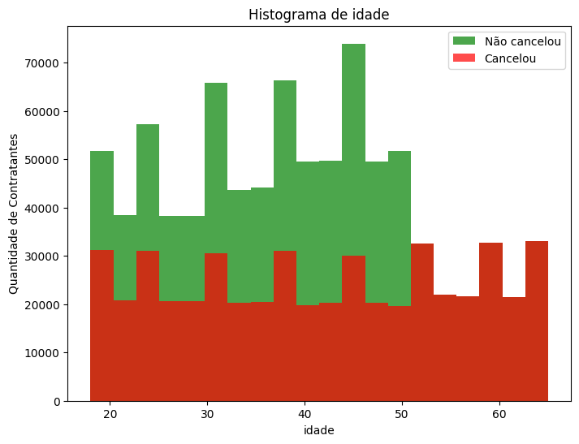

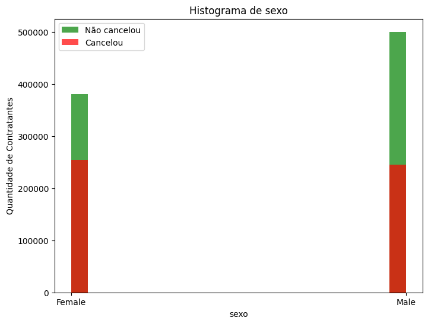

```python
for i in range(0,2):
    plt.figure(figsize=(8, 6))
    plt.hist(df[colunas[i]], bins=20, color='green', alpha=0.7, label='Não cancelou')
    plt.hist(df[df['cancelou'] == 1][colunas[i]], bins=20, color='red', alpha=0.7, label='Cancelou')

    plt.xlabel(colunas[i])
    plt.ylabel("Quantidade de Contratantes")
    plt.title("Histograma de " + colunas[i])
    plt.legend()

    plt.show()
```

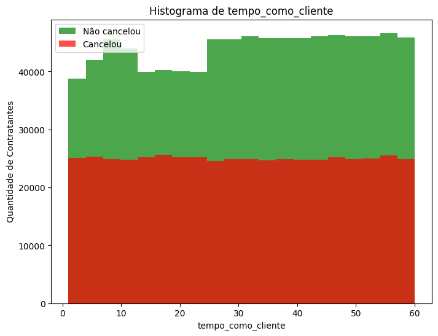

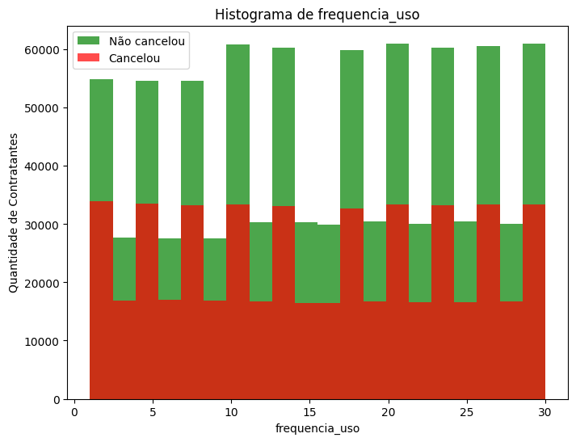

```python
for i in range(2,4):
    plt.figure(figsize=(8, 6))
    plt.hist(df[colunas[i]], bins=20, color='green', alpha=0.7, label='Não cancelou')
    plt.hist(df[df['cancelou'] == 1][colunas[i]], bins=20, color='red', alpha=0.7, label='Cancelou')

    plt.xlabel(colunas[i])
    plt.ylabel("Quantidade de Contratantes")
    plt.title("Histograma de " + colunas[i])
    plt.legend()

    plt.show()
```

#### Tanto o tempo como cliente, quanto a frequência de uso não parecem impactar a quantidade de cancelamentos.

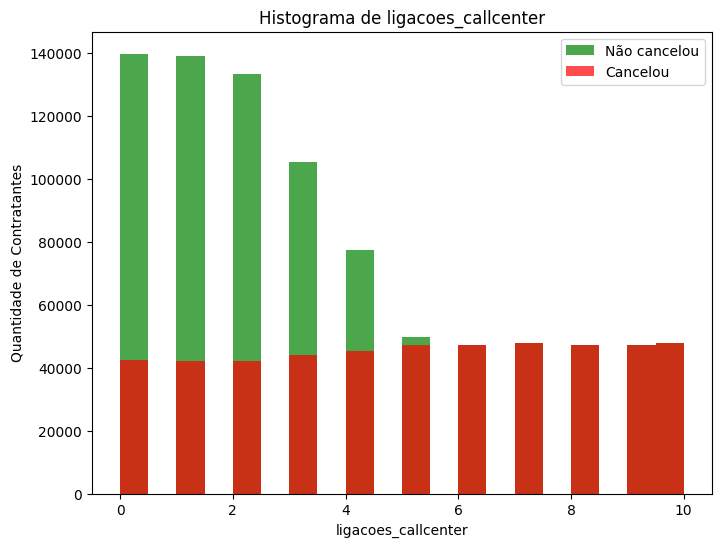

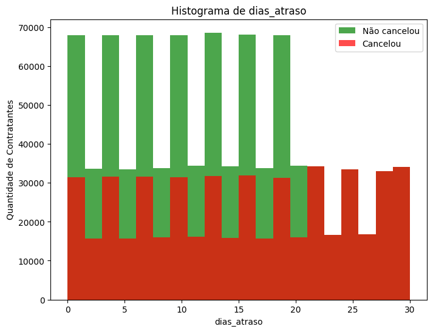

```python
for i in range(4,6):
    plt.figure(figsize=(8, 6))
    plt.hist(df[colunas[i]], bins=20, color='green', alpha=0.7, label='Não cancelou')
    plt.hist(df[df['cancelou'] == 1][colunas[i]], bins=20, color='red', alpha=0.7, label='Cancelou')

    plt.xlabel(colunas[i])
    plt.ylabel("Quantidade de Contratantes")
    plt.title("Histograma de " + colunas[i])
    plt.legend()

    plt.show()
```

#### Analisando os últimos dois gráficos, a quantidade de ligações ao callcenter impactam de forma brusca a partir da quinta ligação. Provavelmente, isso ocorre devido a falta de resolução de problemas. Além disso, a partir do vigésimo dia de atraso, o cliente, com certeza cancelará o serviço. Logo, é possível concluir que após os vinte dias de atraso o cliente já está insatisfeito com o serviço.

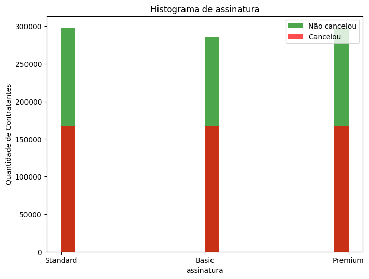

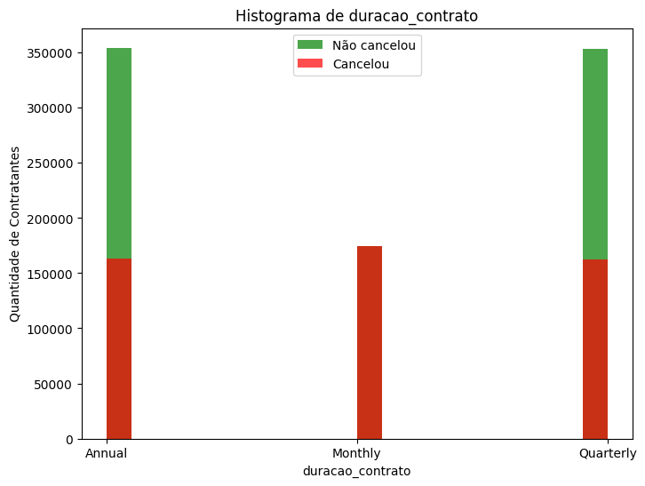

```python
for i in range(6,8):
    plt.figure(figsize=(8, 6))
    plt.hist(df[colunas[i]], bins=20, color='green', alpha=0.7, label='Não cancelou')
    plt.hist(df[df['cancelou'] == 1][colunas[i]], bins=20, color='red', alpha=0.7, label='Cancelou')

    plt.xlabel(colunas[i])
    plt.ylabel("Quantidade de Contratantes")
    plt.title("Histograma de " + colunas[i])
    plt.legend()

    plt.show()
```

#### Em relação ao período da assinatura, é perceptível que há um grande problema em relação a assinatura mensal. Provavelmente, em relação a proporção custo x benefício.

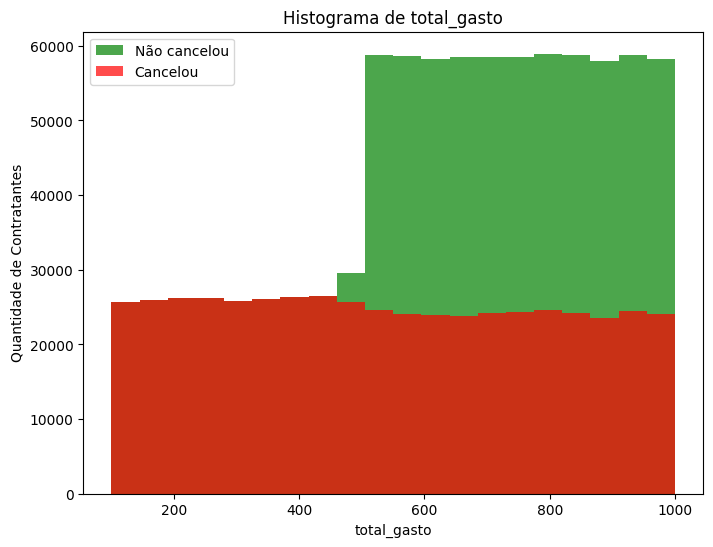

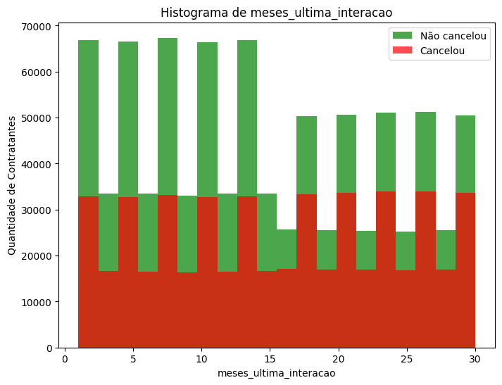

```python
for i in range(8,10):
    plt.figure(figsize=(8, 6))
    plt.hist(df[colunas[i]], bins=20, color='green', alpha=0.7, label='Não cancelou')
    plt.hist(df[df['cancelou'] == 1][colunas[i]], bins=20, color='red', alpha=0.7, label='Cancelou')

    plt.xlabel(colunas[i])
    plt.ylabel("Quantidade de Contratantes")
    plt.title("Histograma de " + colunas[i])
    plt.legend()

    plt.show()
```

#### Podemos perceber que os contratantes com planos abaixo de 500 reais sempre cancelam. Novamente, por conta da relação custo x benefício.

## Possíveis Soluções e Resolvimento de Problemas

#### Fazendo, uma análise mais "bruta" dos principais problemas, temos que:

#### Clientes do cotrato MENSAL sempre cancelam --> Rever preços e beneficíos do plano Clientes que ligam mais de 4 vezes cancelam --> Criar política de PRIORIDADE para resolver problemas de clientes em no máximo 3 ligações e implementar avisos de URGÊNCIA no perfil do cliente que já ligou 2 vezes. Clientes que atrasam mais de 20 dias, também cancelam. --> Criar política e organizar com a equipe financeira para resolver atrasos que passam de 10 dias, ligar para o cliente e enviar e-mails para alertar, além de disponibilizar um canal justamente para que os clientes justifiquem seus atrasos e tentar resolvê-los.

```python
tabela = df[df["duracao_contrato"]!="Monthly"]
tabela = tabela[tabela["ligacoes_callcenter"]<=4]
tabela = tabela[tabela["dias_atraso"]<=20]

display(tabela["cancelou"].value_counts(normalize=True).round(2))
```

```
cancelou
0.0    0.82
1.0    0.18
Name: proportion, dtype: float64
```

#### Resolvendo esses principais problemas, já podemos perceber uma alta diminuição do percentual de clientes que cancelam suas assinaturas.

# Finalizando, vamos fazer um treinamento de IA que irá analisar se o cliente irá cancelar ou não.

### Essa informação pode colaborar na visualização de potenciais perdas de clientes, dessa forma, a equipe poderá focar na resolução de problemas destes assinantes.

```python
# Importando as bibliotecas necessáras...
from sklearn.preprocessing import LabelEncoder
from sklearn.model_selection import train_test_split
from sklearn.metrics import accuracy_score
codificador = LabelEncoder()
```

```python
# Tratando os dados como anteriormente...
df = pd.read_csv("cancelamento.csv")
df = df.dropna()
df = df.drop(columns= "CustomerID")
display(df.info())
```

```
<class 'pandas.core.frame.DataFrame'>
Index: 881649 entries, 0 to 881655
Data columns (total 11 columns):
 #   Column                  Non-Null Count   Dtype
---  ------                  --------------   -----
 0   idade                   881649 non-null  float64
 1   sexo                    881649 non-null  object
 2   tempo_como_cliente      881649 non-null  float64
 3   frequencia_uso          881649 non-null  float64
 4   ligacoes_callcenter     881649 non-null  float64
 5   dias_atraso             881649 non-null  float64
 6   assinatura              881649 non-null  object
 7   duracao_contrato        881649 non-null  object
 8   total_gasto             881649 non-null  float64
 9   meses_ultima_interacao  881649 non-null  float64
 10  cancelou                881649 non-null  float64
dtypes: float64(8), object(3)
memory usage: 80.7+ MB
```

```
None
```

```python
# Como a IA apenas entende números precisamos fazer um pré-processamento de nossos dados, nesse caso, transformar todas as nossas colunas que possuem texto em número.
df['sexo'] = codificador.fit_transform(df['sexo'])
df['assinatura'] = codificador.fit_transform(df['assinatura'])
df['duracao_contrato'] = codificador.fit_transform(df['duracao_contrato'])
```

```python
display(df)
```

[output not shown]

```python
# Quero prever quem cancela, logo chamo de y:
y = df['cancelou']
x = df.drop(columns= "cancelou")

x_treino,x_teste,y_treino,y_teste = train_test_split(x,y,test_size = 0.3) # A ORDEM IMPORTA
```

```python
# Importando as IAs (Usarei RandomForest e KNN)
from sklearn.ensemble import RandomForestClassifier
from sklearn.neighbors import KNeighborsClassifier

modelo_rf = RandomForestClassifier()
modelo_knn = KNeighborsClassifier()

# Treinando a IA
modelo_rf.fit(x_treino , y_treino)
modelo_knn.fit(x_treino , y_treino)
```

```
KNeighborsClassifier()
```

```python
## Escolhendo qual o melhor...
previsao_rf = modelo_rf.predict(x_teste)
previsao_knn = modelo_knn.predict(x_teste)

display(accuracy_score(y_teste,previsao_rf))
display(accuracy_score(y_teste,previsao_knn))
```

```
0.9999395073630881
```

```
0.9121949375224484
```

### Com 99.9% de precisão o melhor modelo é o RandomForest!

#### Provavelmente, por conta dos motivos de cancelamento serem tão evidentes a precisão foi quase perfeita.

```python
# Testando com outros clientes
outros_clientes = pd.read_csv("outros_clientes.csv")
outros_clientes = outros_clientes.drop(columns= "CustomerID")
outros_clientes['sexo'] = codificador.fit_transform(outros_clientes['sexo'])
outros_clientes['assinatura'] = codificador.fit_transform(outros_clientes['assinatura'])
outros_clientes['duracao_contrato'] = codificador.fit_transform(outros_clientes['duracao_contrato'])

previsao = modelo_rf.predict(outros_clientes)
outros_clientes['previsao_cancelamento'] = previsao
display(previsao)
display(outros_clientes)
```

```
array([0., 0., 0., 0., 0., 1., 1., 1., 1., 1.])
```

|  | idade | sexo | tempo_como_cliente | frequencia_uso | ligacoes_callcenter | dias_atraso | assinatura | duracao_contrato | total_gasto | meses_ultima_interacao | previsao_cancelamento |
| --- | --- | --- | --- | --- | --- | --- | --- | --- | --- | --- | --- |
| 0 | 42.0 | 1 | 54.0 | 15.0 | 1.0 | 3.0 | 1 | 0 | 716.38 | 8.0 | 0.0 |
| 1 | 25.0 | 0 | 8.0 | 13.0 | 1.0 | 20.0 | 1 | 0 | 745.38 | 2.0 | 0.0 |
| 2 | 26.0 | 1 | 35.0 | 27.0 | 1.0 | 5.0 | 2 | 2 | 977.31 | 9.0 | 0.0 |
| 3 | 28.0 | 1 | 55.0 | 14.0 | 2.0 | 0.0 | 2 | 2 | 602.55 | 2.0 | 0.0 |
| 4 | 31.0 | 1 | 48.0 | 20.0 | 1.0 | 14.0 | 1 | 2 | 567.77 | 21.0 | 0.0 |
| 5 | 55.0 | 1 | 30.0 | 30.0 | 2.0 | 23.0 | 2 | 1 | 953.00 | 16.0 | 1.0 |
| 6 | 53.0 | 1 | 47.0 | 28.0 | 3.0 | 6.0 | 1 | 1 | 976.00 | 20.0 | 1.0 |
| 7 | 60.0 | 0 | 57.0 | 17.0 | 1.0 | 4.0 | 1 | 1 | 475.00 | 10.0 | 1.0 |
| 8 | 38.0 | 1 | 4.0 | 10.0 | 6.0 | 10.0 | 2 | 2 | 828.00 | 11.0 | 1.0 |
| 9 | 45.0 | 1 | 40.0 | 19.0 | 0.0 | 15.0 | 0 | 0 | 135.00 | 26.0 | 1.0 |

#### PS: Me contate através do meu Linkedin, caso há algum tipo de otimização a ser feita no código! Sua ajuda será apreciada. Obrigado!